# Goncalves Modelling (Model Selection via Maximum Likelihood)

Florian Bach

21/03/2022

## Hypotheses

To further characterise the the best model to describe the risk dynamics of severe disease we will use maximum likelihood estimation and AIC to test several models:

1. The risk of severe disease is constant across infections
2. The risk of severe disease declines at a constant rate with the number of infections.
3. The risk of severe disease drops sharply from 1st to 2nd infection in life and then declines at a constant rate.
4. The risk of severe disease declines exponentially.

As a reminder, on the left are the fractions we’re modelling. To deal with missing data at infections 12 & 13 I used weighted linear regression of non-`NA`, log-transformed case counts to model the number of cases at each infection (dashed line) and imputed the rounded values at 12 & 13.

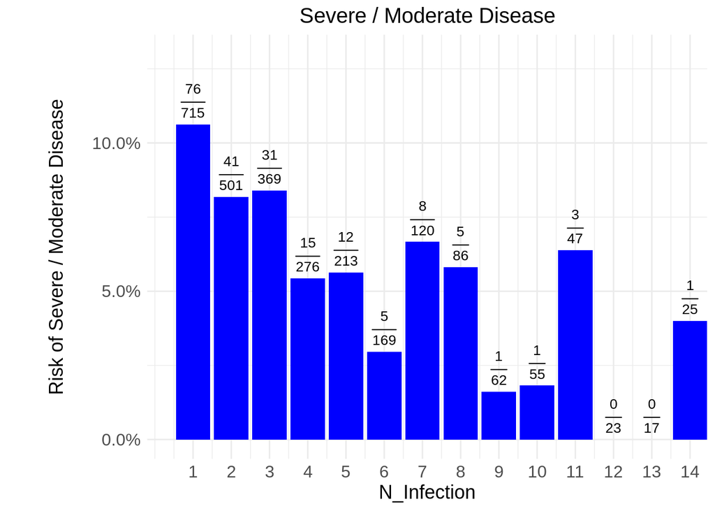

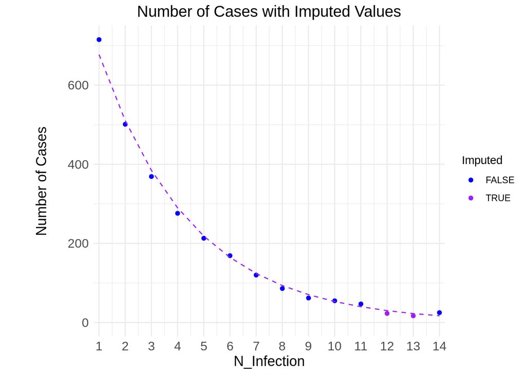

## Model Definitions

We will model the data as derived from a binomial distribution $N \sim {\sf Binom}(M, P_{i})$ where

- $N$ is a vector of successes (i.e. instances of severe disease at each order of infection $i$)
- $M$ is a vector of the number of observations (i.e. number infections at each order of infection $i$)
- $P_{i}$ is a vector of probabilities giving the probability $p$ of success at each trial (i.e. the severe disease risk at each order of infection $i$)

The first two parameters $N, M$ are fixed, as they correspond to the numerator and denominator of the fractions of severe disease, respectively, at each order of infection. The vector of probabilities of success, $P_{i}$, is what we aim to estimate using maximum likelihood. In this format the above hypotheses 1-4) can be rewritten as estimating $P_{i}$ as:

1. $P_{i} = p_{1}$ (constant for all $i$)
2. $P_{i} = p_{1}-\alpha(i-1)$
3. - $P_{i} = p_{1} - \alpha(i-1)$ for $i \leqq j$
   - $P_{i} = p_{1} - \alpha(j-1) - \alpha_2 (i-j)$ for $i > j$
4. $P_{i} = p_{1} e^{-\alpha(i-1)}$

For determining the maximum likelihood I used `stats4::mle()` which implements the Nelder-Mead algorithm (https://doi.org/10.1093/comjnl/7.4.308).

Model Comparison

| Model | P1 | SE(P1) | alpha | SE(alpha) | logL | AIC |
| --- | --- | --- | --- | --- | --- | --- |
| No Decay | 0.0743091 | 0.0050673 | NA | 0.0050673 | -39.84810 | 81.69621 |
| Constant Decay | 0.0873584 | 0.0045200 | 0.0057985 | 0.0002349 | -29.79750 | 63.59501 |
| Exponential Decay | 0.1009023 | 0.0088075 | 0.1364267 | 0.0307710 | -27.83553 | 59.67107 |
| Exponential Decay (glm) | 0.1263383 | 0.0154380 | 0.1360107 | 0.0333581 | -27.01122 | 58.02245 |

Stepwise Models

| P1 | SE(P1) | alpha_1 | SE(alpha_1) | alpha_2 | SE(alpha_2) | j | logL | AIC |
| --- | --- | --- | --- | --- | --- | --- | --- | --- |
| 0.0999171 | 0.0051509 | 0.0034208 | 0.0167789 | 0.0034001 | 0.0167889 | 2 | -30.72549 | 69.45097 |
| 0.0893257 | NaN | 0.0054967 | NaN | 0.0003348 | 0.0002398 | 3 | -29.72419 | 67.44837 |
| 0.0908617 | NaN | 0.0063568 | NaN | -0.0004414 | 0.0002401 | 4 | -29.50759 | 67.01518 |
| 0.0995594 | NaN | 0.0122142 | NaN | -0.0078874 | NaN | 5 | -27.75003 | 63.50006 |
| 0.1021275 | 0.0058547 | 0.0127565 | 0.0011953 | -0.0099821 | 0.0027239 | 6 | -26.90498 | 61.80995 |
| 0.0974354 | 0.0052066 | 0.0095828 | 0.0002514 | -0.0061314 | 0.0020915 | 7 | -28.24499 | 64.48999 |
| 0.0952201 | 0.0051158 | 0.0084923 | 0.0002465 | -0.0053701 | 0.0025518 | 8 | -28.65818 | 65.31636 |

I’ve tweaked the stepwise models a little bit, so now they can be evaluated for any value of j, however adding the extra 3 data points now means that some resulting model parameters are estimated to have negative variance which means their standard error cannot be evaluated. I’ve improved this by setting upper and lower bounds for each variable but currently this is the best I can do.

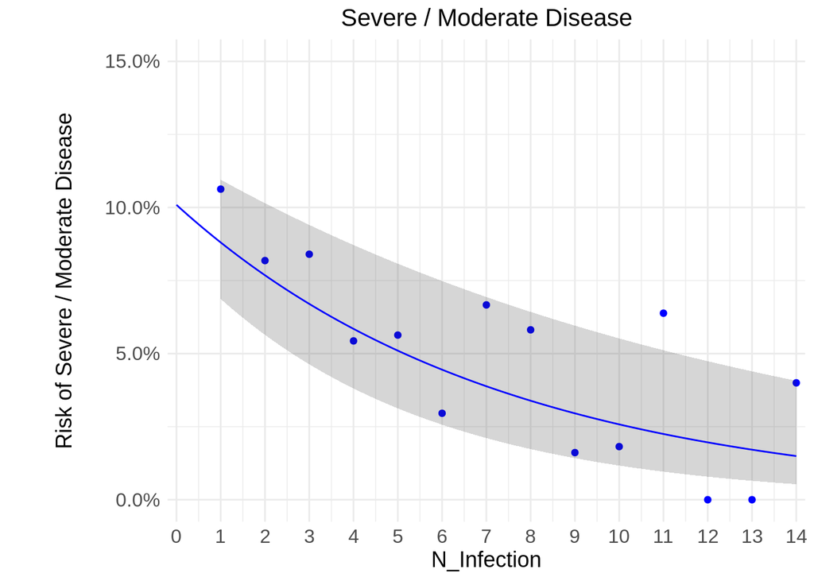

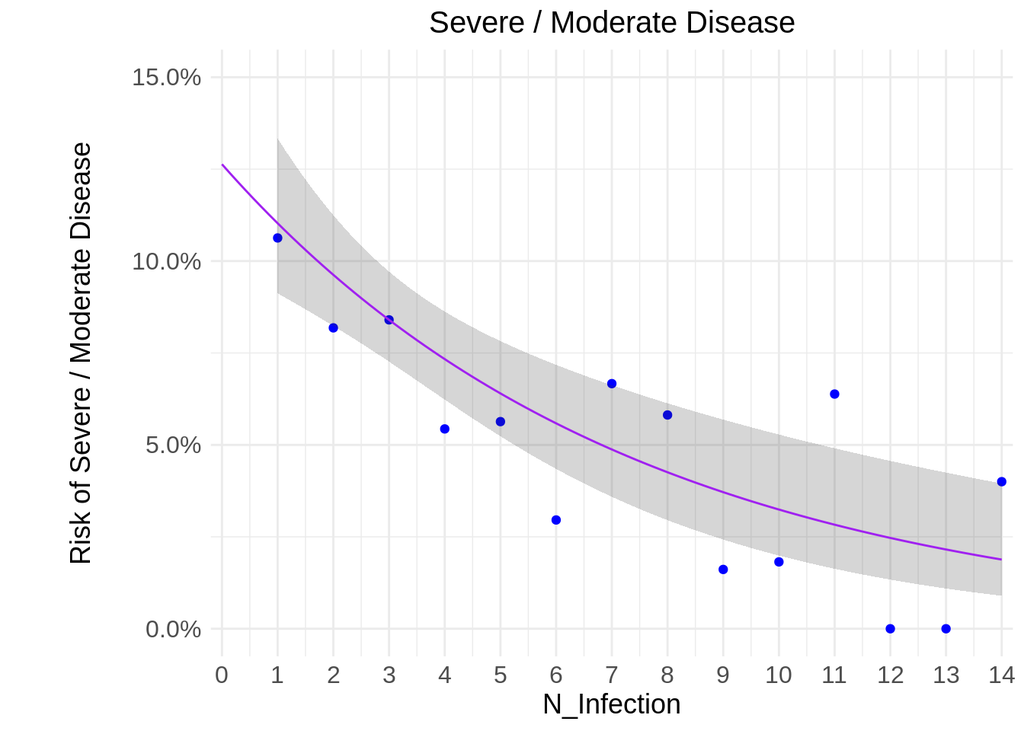